# Older than their fossils? What the Ordovician–Silurian record can test about the maxima that divide land-plant molecular clocks

Internal research draft, Loop 3 reconstruction. Not for release; release and submission are Barry W. Brook’s decision.

Authors

Barry W. Brook

Claude Opus 5.5 and OpenAI Codex (AI roles below)

Published

November 2, 2026

## Abstract

Molecular clocks place the origin of crown land plants anywhere from about 515 to 450 million years ago (Ma), and of crown vascular plants from about 452 to 428 Ma. With the same sequence data, much of that spread follows from fossil calibrations, and above all from maximum ages: claims that a lineage would have left recoverable fossils earlier had it existed. We asked what the sampled Ordovician–Silurian record can actually test about three such maxima: 515.5 and 459.1 Ma for crown land plants, and 431.2 Ma for crown vascular plants. None can be tested as a pure absence. The 515.5 Ma maximum rests on the affinity of Cambrian spore-like fossils, which none of the sources we examined accepts as land-plant, not on sampled absence. For 459.1 Ma, one Libyan basin supplies the only qualified quantitative comparison: 28 older well cuttings without trilete spores against 51 of 59 younger cuttings with them. It limits Late Ordovician trilete encounter to about a tenth of the younger level, but cannot say whether that reflects rare producers or poor delivery, and its verdict depends on assumed contamination and dating. For vascular plants we analysed 48 dated crown-member localities. If recovery was constant, or tracked collecting effort, crown vascular-plant bodies entered the recoverable record no earlier than about 429 Ma (95% bound), consistent with the young clock. The same methods, applied to all land-plant bodies, put their start 21–24 Myr after land-plant spores are certainly present, so bodies demonstrably lagged the lineage once in this system. If recovery before the Ludlow was a tenth of later levels, the bound moves to 448 Ma, overlapping older clock estimates. The record within its observed range cannot distinguish these cases. Under plausible assumptions the evidence is therefore compatible with an older, sparsely recorded early flora; it does not require one.

## 1. Why fossil maxima decide the age of land plants

When did plants colonise the land, and how fast did the vascular plants that came to dominate it diversify? Molecular clocks give strikingly different answers (Fig. 1). Morris et al. (2018) placed crown Embryophyta (the last common ancestor of living land plants and all its descendants) at 515–474 Ma across seven topologies, and Harris et al. (2022) at 515–493 Ma. Hooper et al. (2026), using the same molecular dataset as Harris et al. but recalibrated fossils, obtained 457–450 Ma: a crown-group mean 55 Myr younger. For crown Tracheophyta (living vascular plants) the estimates are 451–419 Ma (Morris et al.), 452–447 Ma (Harris et al.) and 432–428 Ma (Hooper et al.). Su et al. (2021) obtained still older crown-embryophyte ages with a Proterozoic maximum. These are disagreeing results, not one uncertain estimate.

The difference matters biologically. If crown land plants are Cambrian, they existed for about 80 Myr before the first recognisable land-plant body fossil, from the Sheinwoodian, about 432 Ma (Libertín et al. 2018). If they are Late Ordovician, that gap shrinks to as little as 19 Myr and the oldest bodies sit close to the root of the living radiation. The two readings imply different histories of terrestrial productivity, weathering and the assembly of the plant body plan (Kenrick et al. 2012; Strother & Foster 2021; Donoghue et al. 2021).

Fossils enter clocks as minima and maxima. A minimum rests on a dated fossil whose placement can be argued. A maximum rests on what was not found: older rocks that should have yielded the diagnostic fossil if the lineage had existed. Hooper et al.’s recalibration shows how much rides on that argument. Where Morris et al. set the crown land-plant maximum at 515.5 Ma from Cambrian cryptospores, Hooper et al. set it at 459.1 Ma from the oldest trilete spores, and they set 431.2 Ma for crown vascular plants. The use of absence-based maxima is itself contested (Hedges et al. 2018; Su et al. 2021).

A maximum makes two claims that are easily run together (Fig. 4). The first concerns recovery: that sampled rocks of the right age, facies and preparation would have yielded the fossil if its producers were present at some stated abundance. The second concerns biology: that the producing lineage made the diagnostic spore or body from its origin, so the first recoverable fossil can stand in for the node. Early land plants strain both. Land-plant spores appear about 40 Myr before land-plant bodies (Wellman & Gray 2000). Terrestrial deposits are scarce before the latest Silurian, at least in western Europe (Kenrick et al. 2012). The oldest parent plants known in detail are minute, and bryophyte-grade plants lack lignin and preserve poorly (Edwards et al. 2014; Morris et al. 2018).

We therefore asked what each of the three maxima would need from the sampled record, and then tested what the record allows. The work had three parts:

1. **An audit** of the observations behind each maximum, keeping the specimen, its identification, the sampling evidence, the persistence of the diagnostic trait and the node it bears on as separate links.
2. **An absence test** wherever an older-empty, younger-positive spore comparison could be built from documented samples.
3. **A positive-record analysis** of dated body fossils, which estimates how far before the oldest find the recoverable record probably began, under declared recovery histories.

The third part needs no inventory of searched but empty rock; it substitutes an assumption about how recovery behaved before the first find, and we vary that assumption explicitly.

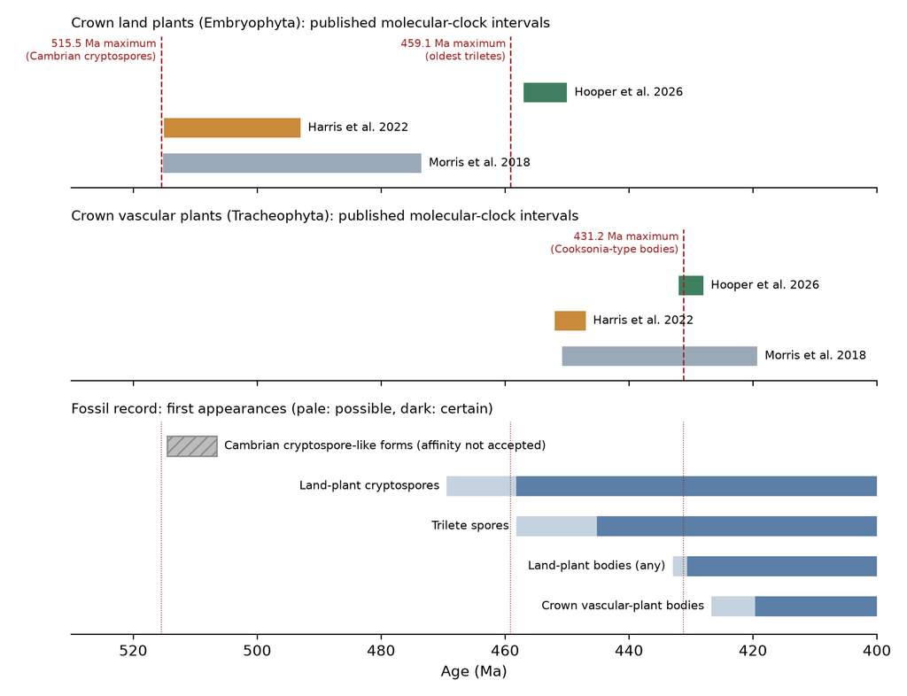

Figure 1: The problem. Top two panels: published crown-age intervals from three molecular-clock studies (Morris et al. 2018; Harris et al. 2022; Hooper et al. 2026), with the three calibration maxima examined here (dashed). Bottom: first appearances of four fossil channels. Pale bars run from the oldest possible to the oldest certain occurrence; for spores these are the strict-set first appearances of the project compilation, and for bodies they are the reviewed locality units of this study. The hatched bar marks Cambrian Stage 4 cryptospore-like forms, whose land-plant affinity none of the sources examined accepts.

## 2. Evidence, its geography and its independence

Three bodies of evidence carry the tests (Fig. 2).

**Murzuq Basin cuttings.** Abuhmida (2013) reported palynology from Ordovician to lower Silurian wells in southwest Libya. We transcribed all 164 appendix samples and their chart and prose reports, and used the chart-coded cuttings of five wells as the primary frame. Three wells supply 28 cuttings older than the Llandovery, none reporting trilete spores, and all five supply 59 Llandovery reference cuttings, 51 of which report them. Northern Africa lay near the Ordovician South Pole, within the area of Hirnantian glaciation (Cocks & Torsvik 2021; Scotese et al. 2021), so this frame samples one high-latitude basin.

**QSIM-801.** Vecoli et al. (2017) tabulate 99 cryptospore occurrences in 17 of 20 samples from a Saudi Arabian borehole assigned to the late Dapingian–early Darriwilian, and report no trilete spores in the studied sequence. The material and basin are independent of Murzuq.

**Dated body fossils.** We assembled the accepted land-plant body occurrences from 445 to 393 Ma that could be dated and linked to a locality. Sources were the Paleobiology Database (PBDB) names, classified by AI with cited sources and audited, together with our curated set of the oldest records and their competing readings. The audit also covered a separate screen of all 556 older non-spore PBDB rows. The counting unit is a locality–age proxy, so several collections, taxa or papers from one horizon count once. The main reading yields 77 land-plant body units, 72 of polysporangiophytes (branched sporophytes with several sporangia) and 50 of crown vascular-plant members (the lycophyte line or euphyllophytes). Of these, 75, 70 and 48 are certainly older than the end of the Emsian (393.47 Ma).

The body record is geographically concentrated where it matters most. Of the 48 crown vascular-plant units, only 16 have age support older than the Silurian–Devonian boundary, and those come from eight regions. The two oldest-possible clusters are Yea, Victoria (two horizons whose age is disputed between Gorstian and Early Devonian; Earp 2024) and Bathurst Island, Arctic Canada (Ludfordian; Kotyk et al. 2002). Silurian land-plant bodies more generally come mainly from Laurentia (11 of 34 wholly Silurian units) and peri-Gondwanan Europe (8). Laurentia supplies 29 of the 77 land-plant units, most of them Devonian.

Three comparisons are independent of one another in material: Murzuq, QSIM and the body record. Within each, independence is limited. Murzuq’s 87 cuttings come from five wells, and its older cuttings from three. Body units share regions and collectors, and their proxy for a horizon is not a verified bed. None is independent of the clocks in the way a validation would need. The oldest *Cooksonia* and Ludlow *Zosterophyllum* are themselves calibrations, and the oldest trilete spores set a maximum. Agreement between a body-record bound and a clock therefore tests whether an absence-based maximum is reasonable; it does not validate a clock posterior.

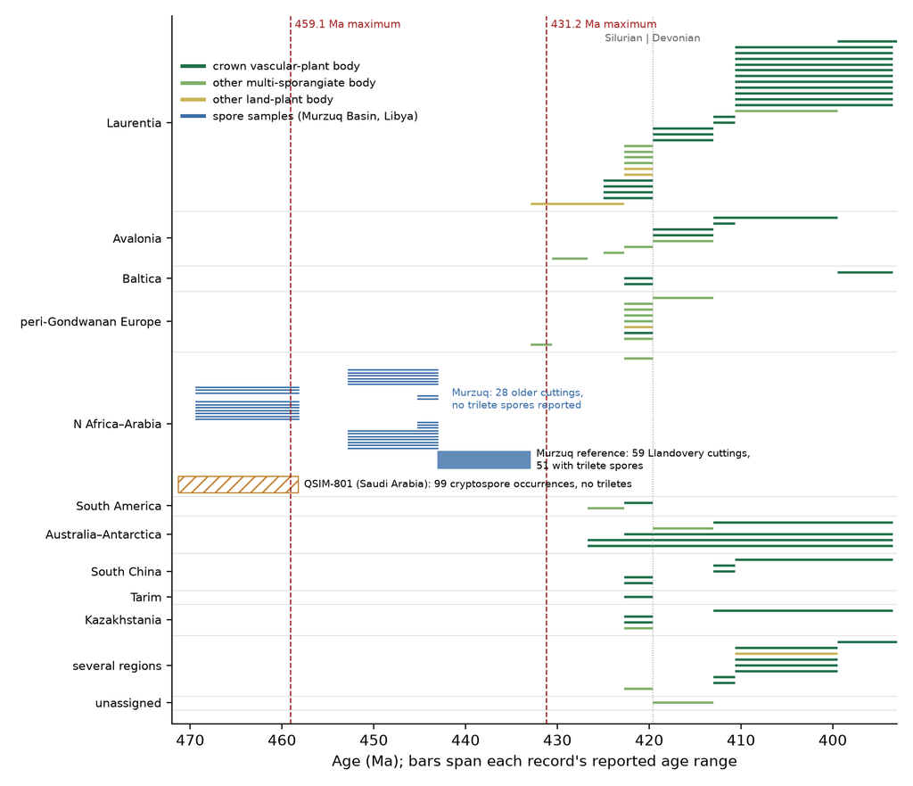

Figure 2: Where the tested evidence comes from. Body-fossil locality units (main reading) by palaeogeographic region; bars span reported age ranges, coloured by the most specific category each unit supports. Blue: Murzuq Basin cuttings used in the spore test (older cuttings without trilete reports, and the Llandovery reference block). Hatched: QSIM-801 cryptospore samples (full-stage enclosure; the source assigns them more finely, to the late Dapingian–early Darriwilian). Regions follow approximate modern country or state assignments, not a palaeogeographic reconstruction. Spore records outside these two frames are not shown.

## 3. Results

### 3.1 Crown land plants before 515.5 Ma: a question of affinity, not absence

The 515.5 Ma maximum of Morris et al. (2018) rests on Cambrian cryptospore-like packets and polyads. Of the three sources we examined, none accepts them as land-plant spores. Strother (2016) placed the Tennessee taxa in Charophyta, Taylor & Strother (2024) read the packets as pre-embryophytic, and Wang et al. (2022) favoured ancestral aeroterrestrial algae while calling an embryophyte affinity unlikely. More decisively, the material is Stage 4, 514.5–506.5 Ma on our timescale, and so younger than the maximum itself. Even accepting it would neither contradict 515.5 Ma nor establish crown membership. No assessed source documents productive sampled material older than 515.5 Ma in which land-plant spores would have been reported. This maximum cannot be tested from the sampled record; it is a judgement about affinity.

### 3.2 Crown land plants before 459.1 Ma: one quantitative test, conditional on recovery

The 459.1 Ma maximum of Hooper et al. (2026) rests on the oldest possible trilete spores. Under their ancestral-state reconstruction, trilete monads mark total-group land plants, so a crown older than 459.1 Ma would imply undetected trilete producers. Murzuq is the only frame we found in which that implication can be confronted with documented older and younger samples.

We modelled each cutting’s chance of reporting triletes as an encounter process sharing a well effect, with older encounter intensity expressed as a fraction *f* of the Llandovery reference. An assumed delivery-and-recovery ratio *ρ* covers differences in transport, preservation and preparation between older and younger material. Procedures were checked by simulation on a declared grid and admitted only where coverage reached 0.93 (Supplement S2).

Table 1: What the Murzuq comparison allows: 95% compatibility limits on older trilete-producer intensity as a fraction *f* of the Llandovery reference, primary stage allocation. Rows 1–2 constrain intensity sustained from 459.1 Ma to the reference; rows 3–4 constrain an interval of fixed intensity beginning at 459.1 Ma and extending further back.

| Question asked of the 28 older cuttings | Delivery equal (*ρ* = 1) | Delivery halved | Delivery quartered | Delivery a tenth |
| --- | --- | --- | --- | --- |
| Largest constant producer intensity, 459.1 Ma to the Llandovery | 0.091 | 0.182 | 0.364 | 0.910 |
| Largest intensity, exposure-weighted history class | 0.184 | 0.258 | 0.421 | 0.921 |
| Oldest end of a reference-intensity interval beginning at 459.1 Ma | 462.6 Ma | 464.1 Ma | 467.1 Ma | no limit |
| Oldest end of an interval at 0.1 or 0.01 of reference intensity | no limit | no limit | no limit | no limit |

The result is clear in form and conditional in substance (Table 1). What the zeros constrain is delivered, recovered encounter: the product *ρf* stays near 0.09 across delivery scenarios. If older material delivered and preserved spores as well as the Llandovery reference, trilete producers sustained from 459.1 Ma must have been below a tenth of their Llandovery intensity. If delivery was a tenth as good, producers at nearly the reference intensity are allowed. Intervals of producers at a tenth or a hundredth of reference intensity are unbounded under every delivery scenario. The record therefore rejects abundant, well-delivered Late Ordovician trilete producers in this basin, not sparse or poorly delivered ones, and it cannot tell those two apart.

The verdict also moves with the auxiliary assumptions. Removing one well at a time spans exposure-weighted limits of 0.185–0.365. Shared within-stage age positions can remove all exposure from the 459.1–462.6 Ma window. With no contaminant transfer to older cuttings, a reduction of more than about 4.4% in the indigenous share of reference intensity crosses the short window’s comparison threshold. At that window’s simulated boundary, 20 of 1,000 screen-passing simulations missed the truth, and those 20 were among only 60 that made a claim. The comparison is real and useful, but it is one basin, it sits at a glacial pole, and it depends on preservation and recovery.

QSIM-801 points the same way without reaching the same standard. Treating each of the 99 occurrences as an independent unit on which a trilete would have been detected, a persistent trilete share above about 3% of land-plant spores would be rejected at equal recovery, and above about 31% at a tenth of it. The source does not document the search protocol needed to make those units independent and target-detectable, so we report this as an exploratory, model-conditional calculation, not a second qualified test (Supplement S3).

### 3.3 Crown vascular plants: what the body record allows

No assessed source supplies a roster of searched Silurian beds with comparable effort for the 431.2 Ma maximum. The Irish late-Wenlock sections report fossil-free mudstone qualitatively, without an enumerated roster, and the historical Barrandian axes are selected specimens, not search trials. We therefore turned to the positive record.

**Method.** For a fixed recovery history *w*(*t*), the relative rate at which an existing lineage contributes dated, recoverable occurrences, and *n* independent units after a younger cutoff *c*, the one-sided 95% older bound *T* on the start of the recoverable record solves $U(T) = U(A)\,0.05^{-1/n}$. Here *A* is the oldest unit’s age and $U(a)=\int_c^a w(s)\,ds$. With constant *w* this is the classical confidence interval on a stratigraphic range (Strauss & Sadler 1989; Marshall 1990), and the absolute rate cancels. Interval-dated units enter conservatively: the oldest possible age and the smallest number certainly older than the cutoff. We report the bound for six histories: constant recovery; recovery proportional to PBDB land and marginal-marine collections per Myr, with and without collections that match the plant-filtered extract; and recovery declining exponentially into the past on 25 and 10 Myr timescales, the last also combined with plant-excluded collection density (Supplement S5).

**The known-answer check.** The same calculation for any land-plant body (75 units, oldest the Sheinwoodian *Cooksonia barrandei*) gives bounds of 434.5–437.2 Ma under the four histories that produce one. Land-plant cryptospores are certainly present by 458.2 Ma. The start of the recoverable body record therefore lies 21–24 Myr after the land-plant lineage is known to exist (Fig. 3, top). This does not supply a preservation lag to transfer to vascular plants or an origination date to calibrate against. It does show, in this system, that a lineage can be present for more than 20 Myr before its bodies enter the record at the rate seen later. Under the inclusive reading the Hirnantian Zbrza axes become the oldest land-plant body, and the bound moves to 447.2 Ma under constant recovery, still 11 Myr short of the spores.

**Crown vascular plants.** For the 48 crown-member units the bounds are tightly grouped under the histories tied to the observed record: 428.8 Ma for constant recovery, 428.9 Ma for collection density and 428.5 Ma with plant-matched collections removed (Table 2). These fall within Hooper et al.’s 432–428 Ma interval and are younger than their 431.2 Ma maximum. A 25 Myr decline into the past gives 431.6 Ma. A 10 Myr decline gives no bound within the 469.4 Ma limit of the effort history.

Table 2: Conservative 95% older bounds (Ma) on the start of the recoverable body record, main reading, conditional on each recovery history and on independent units. † Retrospective sensitivity chosen after the main analysis; not a nominal 95% bound.

| Recovery history | Land-plant body | Polysporangiophyte | Crown vascular plant |
| --- | --- | --- | --- |
| Constant | 434.5 | 434.6 | 428.8 |
| Proportional to PBDB collection density | 436.4 | 436.6 | 428.9 |
| Collection density, plant-matched collections removed | 435.7 | 435.9 | 428.5 |
| Declining into the past, 25 Myr timescale | 437.2 | 437.5 | 431.6 |
| Declining into the past, 10 Myr timescale | none ≤ 469.4 | none ≤ 469.4 | none ≤ 469.4 |
| Constant, recovery before 426.7 Ma reduced tenfold† | 446.7 | 447.7 | 448.1 |
| Constant, recovery before 426.7 Ma reduced a hundredfold† | none ≤ 469.4 | none ≤ 469.4 | none ≤ 469.4 |

These numbers are robust to most data choices and sensitive to a few (Supplement Tables S4–S6). Counting individual collections instead of locality proxies gives 428.0 Ma, and restoring wide-age records 428.1 Ma. Leaving out each region in turn gives 427.2–430.5 Ma: the youngest without the Australian–Antarctic records (including Yea), the oldest without Laurentia. Ending the window at the Silurian–Devonian boundary, which leaves 13 mainly Silurian units, gives 428.5 Ma, so the result is not an artefact of the dense Devonian record. The bound grows when effective density falls. Collapsing units to region–stage cells (20 units) gives 432.1 Ma, and the curated oldest-record set alone (15 units) gives 434.05 Ma.

**What the record can and cannot test.** The observed age sequence can reject some recovery histories. A steep (10 Myr) decline into the past fits the crown-member sequence poorly: nominal goodness-of-fit *p* values of about 10⁻¹¹ to 10⁻⁶ across age allocations, against 0.07–0.77 for constant recovery. The 25 Myr decline and plant-excluded density also fit poorly. The unbounded and 431.6 Ma cases should therefore not be read as equally supported alternatives. The observed sequence says nothing about recovery before the oldest possible crown-member find. Suppose crown vascular plants existed, but their bodies were recovered at a tenth of the later rate before the Ludlow (426.7 Ma). The fitted records would look exactly the same, and the bound would move to 448.1 Ma; at a hundredth there is no bound. These are retrospective sensitivities, not confidence statements, but they show where the answer is decided: in an interval the body record cannot see.

Finally, a recoverability endpoint is not a crown date. Mapping one to the other needs an assumed delay between crown origin and the recoverable presence of crown-diagnostic bodies. With constant recovery, reaching the young end of Harris et al.’s interval (447 Ma) requires a delay of about 18 Myr; a 20 Myr delay maps 428.8 Ma to 448.8 Ma. The record does not estimate that delay.

Simulations at the real unit counts confirm that the calculation behaves as stated when its assumptions hold (exact-age coverage 0.941–0.958) and show how it fails when they do not. Duplicated horizons treated as independent cut coverage to about 0.78 (pairs) or 0.53 (quartets). Fitting constant recovery to a true 10 Myr decline gives 0.03–0.24. An ignored 10–20 Myr origin-to-body delay can give zero coverage of the lineage age (Supplement S5.6, Table S11).

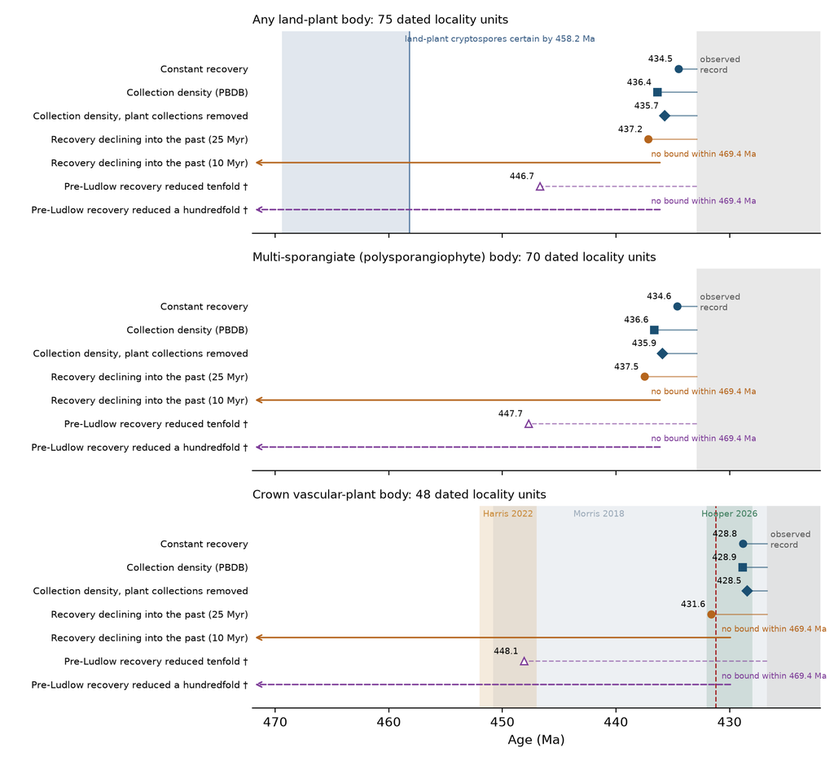

Figure 3: Older bounds on the start of the recoverable body record. Each row is one declared recovery history; points are conservative 95% older bounds conditional on that history and on independent locality units (main reading). Grey: span of the observed units. Open triangles (†) are retrospective sensitivities in which recovery before 426.7 Ma is reduced; for the crown-member category they leave the fit to the observed record unchanged. Top: blue shading marks land-plant cryptospores, possible from 469.4 Ma and certain by 458.2 Ma. Bottom: shaded bands are published crown vascular-plant intervals and the dashed line is the 431.2 Ma maximum; they are comparators, not validation targets. Arrows: no bound within the 469.4 Ma limit of the declared histories.

## 4. What follows for early land-plant evolution

### 4.1 An older, sparsely recorded flora is allowed, not required

Taken together, the three tests support a specific, conditional conclusion. Where the record can be interrogated, it rules out early land plants that were both abundant and recoverable before the younger dates: no well-delivered, Llandovery-level trilete producers in Late Ordovician Murzuq, and no crown vascular-plant bodies recovered at the later Silurian–Devonian rate before about 429 Ma. It does not rule out early land plants that were rare, small or poorly preserved. Murzuq allows trilete producers at a tenth of their later intensity, or at full intensity with poor delivery. The body record allows crown vascular plants that were present but recovered at a tenth of later rates, or that lacked crown-diagnostic bodies, before the Ludlow.

Whether those allowances are plausible is a biological question, and the record gives one direct handle on it. Land plants as a whole were present for more than 20 Myr before their bodies entered the recoverable record at the rate seen afterwards. A lag of that kind is therefore an observed feature of this system, not a special pleading invoked to rescue old clock dates. The record does not show how long any such lag lasted for crown vascular plants. Recoverable bodies need size, cuticle and lignified tissue, and those traits evolved along the lineages being dated. Terrestrial deposits are scarce before the latest Silurian (Kenrick et al. 2012), and the oldest unequivocal body fossil is preserved in marine sediments (Libertín et al. 2018). In our judgement, a tenfold lower pre-Ludlow recovery is therefore not extreme, but neither is it demonstrated.

The young clock of Hooper et al. is thus consistent with the record under the simplest recovery assumptions, and its 431.2 Ma maximum is conservative relative to our bounds under those assumptions. Harris et al.’s interval, and the Morris et al. means near 444 Ma, need one of two things: a long early phase in which crown vascular plants were rare or poorly recoverable as bodies, or crown-diagnostic body features that arose about 15–23 Myr after the crown node (under constant recovery). The record within its observed range cannot discriminate between these possibilities and the young clock. The disagreement among clocks is thus largely a disagreement about recovery and trait history in an interval that leaves few bodies, and fossil maxima set there should carry that uncertainty explicitly instead of hiding it in a soft-bound tail probability.

### 4.2 Which conclusions depend on which assumptions

Table 3: Dependence of each main conclusion on recovery assumptions and on the character-to-lineage mapping.

| Conclusion | Rests on | Fails if |
| --- | --- | --- |
| Murzuq excludes abundant, well-delivered trilete producers through the Late Ordovician | encounter model; delivery *ρ*; reference purity; stage dating of cuttings | older delivery was much lower, reference triletes include caved or recycled grains, or ages are shifted |
| That exclusion bears on crown land plants | trilete production at the embryophyte crown and its persistence (Hooper et al. 2026); our persistence pilot | the ancestral land plant did not make trilete monads, or they were lost in lineages present in the basin |
| Recoverable crown vascular-plant bodies began after about 429 Ma | recovery history before and within the record; unit independence; ages within reported ranges | pre-Ludlow recovery was much lower; units are pseudoreplicated; Yea or Bathurst ages are wrong |
| That bound bears on the crown vascular-plant node | lycophyte-line and euphyllophyte bodies are crown members; crown-diagnostic bodies arose near the node | crown origin preceded recognisable crown bodies by a long delay |
| Bodies lag the land-plant lineage by more than 20 Myr | accepted cryptospores are land-plant; body bounds as above | cryptospore affinity is wrong; recovery rose steeply before the Silurian |

The two right-hand columns of Table 3 separate assumptions about how fossils were recovered from assumptions about what the fossils were. The second kind cannot be tested by sampling at all: no amount of searched rock establishes that a body with sporangia but no demonstrated tracheids belongs to the vascular crown, or that a trilete mark means an embryophyte producer. Our pilot of specimen-to-node links shows that some of these links are supported under declared models. For example, under stochastic-mapping models fitted to Hooper et al.’s deposited data, a trilete aperture present at the land-plant crown persists to the vascular-plant crown with probability 0.977. Others, notably the link from the oldest branched sporophytes to vascular crown membership, remain contested (Supplement S6).

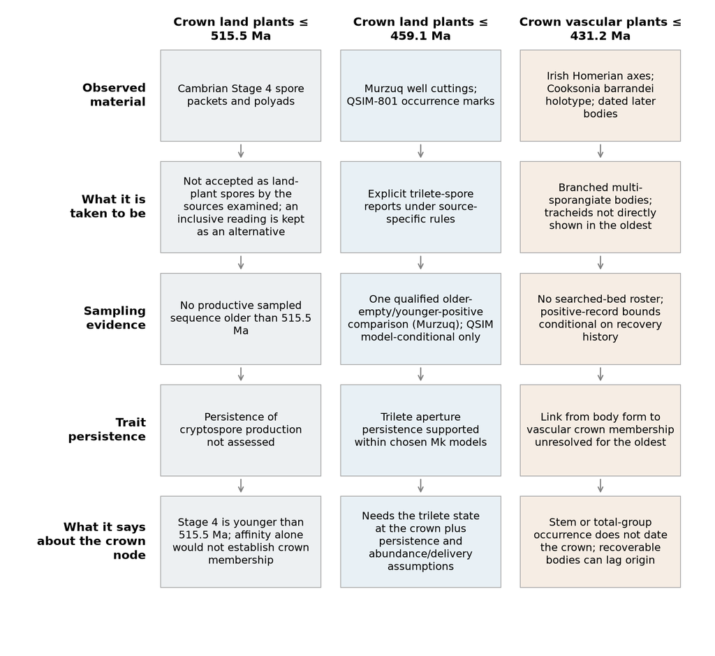

Figure 4: From observed material to node interpretation. For each maximum, the observed material, what it is taken to be, the sampling evidence, the persistence of the diagnostic trait and the implication for the crown node are separate links; a maximum needs all five.

### 4.3 What would sharpen the answer

Four kinds of evidence would most improve these inferences. Any author could use them, and none is requested here.

1. Documented searched-but-empty Silurian non-marine beds with stated effort, which would turn the body record’s untestable pre-Ludlow recovery into an estimable quantity.
2. A second older-empty, younger-positive spore sequence outside polar Gondwana, with counted target and control grains.
3. Finer, independent dating of the Yea and Bathurst Island horizons, which set the crown-member bound.
4. Anatomical demonstration of tracheids in the oldest polysporangiate bodies, which would replace an assumed character-to-node link with an observed one.

## 5. Conclusions

The fossil maxima that most divide land-plant clocks cannot be justified or rejected by absence alone. One cannot be tested at all from the sampled record. One has a single qualified test, in one polar basin, and that test excludes abundant, well-delivered early producers but not sparse or poorly delivered ones. The third is consistent with the positive body record under representative recovery, but becomes compatible with much older crown ages if recovery before the Ludlow was low. The record shows that land-plant bodies lagged the land-plant lineage by more than 20 Myr. An older, sparsely recorded early flora is therefore a live possibility under assumptions that the record itself cannot test. Clock analyses should treat these maxima as conditional on stated recovery and character assumptions, and propagate them as such.

## Methods in brief

All ages use the ICS v2024/12 stage bases held in the project timescale. Literature dated to GTS2012 was converted at stage level, with source-specific statements retained. Each analysis declares a named reading of disputed identifications (main or inclusive). An explicit non-detection is scoped to the material examined; a missing report becomes a zero only after a full reporting audit. The Murzuq encounter model, its simulation-based qualification and the contamination identification result are in Supplement S2. The QSIM floor calculation and its proof are in S3, and the Cambrian affinity review in S4. The body-record inventory, unit rules, age envelope, recovery histories, shape diagnostics, sensitivity grids and simulations are in S5, and the specimen-to-node pilot in S6. Supplement S7 records analyses superseded during review and why.

## Roles of AI systems and humans

Barry W. Brook set the programme and its stages and directed the reconstruction of this paper. He authorised the AI collaborators to proceed on routine decisions and retains decisions on external correspondence, release and submission. This is an internal draft awaiting his final review.

Claude Opus 5.5 (Anthropic, `claude-opus-5-5`, in Claude Code) developed the absence-test framing and engine and led the first modelling loop. It proposed the QSIM floor argument, reviewed the Cambrian affinity sources, and proposed and piloted the positive body-record analysis. It also drew the manuscript figures and wrote this reconstruction and its supplement.

OpenAI Codex (GPT-6; the exact variant was not exposed to it) implemented the Murzuq observation audit and the second loop’s corrections. It reviewed the body-record pilot and replaced its estimator, units and source matching after finding material defects, then implemented the reviewed body-record analysis, simulations and sensitivity grids.

Bounded delegates of both systems contributed. `gpt-6.1-sol` with web search classified the 241 PBDB plant names with cited sources. Codex and Claude subagents independently checked the mathematics, the transcribed tables and the source claims. Each agent reviewed the other’s work. Agreement between the two is not independent validation, and disagreements are kept visible in the audit record. Exact roles, versions and reviews are in `docs/charter.md`, `docs/decisions.md` and `docs/audits/`.

## Data and code

The repository holds the source-linked derived tables, model code, frozen qualification evidence, reviewed body-record outputs with hash receipts, figure and table scripts, and the audit trail. Copyrighted source texts and third-party deposits are not redistributed; scripts fetch the deposits and verify their hashes. Public release is Barry W. Brook’s decision.

## References

- Abuhmida FH (2013). Palynological analysis of the Ordovician to Lower Silurian sediments from the Murzuq Basin, southwest Libya. PhD thesis, University of Sheffield.
- Cocks LRM, Torsvik TH (2021). Ordovician palaeogeography and climate change. Gondwana Research 100: 53–72. https://doi.org/10.1016/j.gr.2020.09.008
- Donoghue PCJ, Harrison CJ, Paps J, et al. (2021). The evolutionary emergence of land plants. Current Biology 31: R1281–R1298. https://doi.org/10.1016/j.cub.2021.07.038
- Earp C (2024). Notanopliid brachiopods and associated fossils from the Yea area, central Victoria: a key to resolving age and correlation problems in a complex geological setting. Proceedings of the Royal Society of Victoria 136. https://doi.org/10.1071/rs23021
- Edwards D, Feehan J (1980). Records of Cooksonia-type sporangia from late Wenlock strata in Ireland. Nature 287: 41–42. https://doi.org/10.1038/287041a0
- Edwards D, Morris JL, Richardson JB, Kenrick P (2014). Cryptospores and cryptophytes reveal hidden diversity in early land floras. New Phytologist 202: 50–78. https://doi.org/10.1111/nph.12645
- Harris BJ, Clark JW, Schrempf D, et al. (2022). Divergent evolutionary trajectories of bryophytes and tracheophytes from a complex common ancestor of land plants. Nature Ecology & Evolution 6: 1634–1643. https://doi.org/10.1038/s41559-022-01885-x
- Hedges SB, Tao Q, Walker M, et al. (2018). Accurate timetrees require accurate calibrations. Proceedings of the National Academy of Sciences 115. https://doi.org/10.1073/pnas.1812558115
- Hooper J, Worth AM, Wellman CH, Clark JW, Donoghue PCJ (2026). Reconstructing spore evolution recalibrates the timescale of land plant diversification. Nature Plants. https://doi.org/10.1038/s41477-026-02432-3
- Kenrick P, Wellman CH, Schneider H, et al. (2012). A timeline for terrestrialization: consequences for the carbon cycle in the Palaeozoic. Philosophical Transactions of the Royal Society B 367: 519–536. https://doi.org/10.1098/rstb.2011.0271
- Kotyk ME, Basinger JF, Gensel PG, et al. (2002). Morphologically complex plant macrofossils from the Late Silurian of Arctic Canada. American Journal of Botany 89: 1004–1013. https://doi.org/10.3732/ajb.89.6.1004
- Libertín M, Kvaček J, Bek J, et al. (2018). Sporophytes of polysporangiate land plants from the early Silurian period may have been photosynthetically autonomous. Nature Plants 4: 269–271. https://doi.org/10.1038/s41477-018-0140-y
- Marshall CR (1990). Confidence intervals on stratigraphic ranges. Paleobiology 16: 1–10. https://doi.org/10.1017/s0094837300009672
- Morris JL, Puttick MN, Clark JW, et al. (2018). The timescale of early land plant evolution. Proceedings of the National Academy of Sciences 115: E2274–E2283. https://doi.org/10.1073/pnas.1719588115
- Scotese CR, Song H, Mills BJW, et al. (2021). Phanerozoic paleotemperatures: The earth’s changing climate during the last 540 million years. Earth-Science Reviews 215: 103503. https://doi.org/10.1016/j.earscirev.2021.103503
- Strauss D, Sadler PM (1989). Classical confidence intervals and Bayesian probability estimates for ends of local taxon ranges. Mathematical Geology 21: 411–427. https://doi.org/10.1007/bf00897326
- Strother PK (2016). Systematics and evolutionary significance of some new cryptospores from the Cambrian of eastern Tennessee, USA. Review of Palaeobotany and Palynology 227: 28–41. https://doi.org/10.1016/j.revpalbo.2015.10.006
- Strother PK, Foster C (2021). A fossil record of land plant origins from charophyte algae. Science 373: 792–796. https://doi.org/10.1126/science.abj2927
- Su D, Yang L, Shi X, et al. (2021). Large-scale phylogenomic analyses reveal the monophyly of bryophytes and Neoproterozoic origin of land plants. Molecular Biology and Evolution 38: 3332–3344. https://doi.org/10.1093/molbev/msab106
- Taylor WA, Strother PK (2024). Ultrastructure of Cambrian cryptospores and the early evolution of the plant spore wall. Fossil Imprint 80: 90–106. https://doi.org/10.37520/fi.2024.009
- Vecoli M, Wellman CH, Gerrienne P, Le Hérissé A, Steemans P (2017). Middle Ordovician cryptospores from the Saq-Hanadir transitional beds in the QSIM-801 well, Saudi Arabia. Revue de Micropaléontologie 60: 319–331. https://doi.org/10.1016/j.revmic.2017.06.003
- Wang K, Xu H-H, Yin L-M (2022). A palynological assemblage from the Cambrian (Series 2, Stage 4) of Shandong Province, China, and its implications to the transition from algae to land plants. Review of Palaeobotany and Palynology 301: 104645. https://doi.org/10.1016/j.revpalbo.2022.104645
- Wellman CH, Gray J (2000). The microfossil record of early land plants. Philosophical Transactions of the Royal Society B 355: 717–732. https://doi.org/10.1098/rstb.2000.0612